# Trabalho Final de Conceitos de Estatisticas pa IA - MBA em IA e ML

Autores: Ariel Rodrigues Miranda Duan Nunes Alves da Silva Jenifer Caroline Correa da Silva Juliana Fatima dos Santos

Outubro de 2018

### Instalação dos pacotes necessários para o desenvolvimento do trabalho

```r
pacotes = c('psych', 'dplyr', 'plotly', 'gmodels','ggplot2','lattice','caret','rpart','corrgram','rpart.plot','latticeExtra','asbio','car','reprex')

loadLibs = function (lista){
  # Run through the list with libs names
  for (x in lista){
    # If not in require, then install the lib
    if (!require(x, character.only = TRUE)){
      install.packages(x, dependencies = TRUE)
      # Apply the value in require, for load the lib in R
      sapply(x, library, character.only = TRUE)
    }
  }
}

loadLibs(pacotes)
```

Mostrar até 2 casas decimais

```r
options("scipen" = 2)
```

Ler arquivo csv

```r
setwd('D:/Juliana/MBA IA and ML/6 - Estatistica')
Vinhos <- read.csv2("BaseWine_Red_e_White2018.csv", row.names=1)
fix(Vinhos)
```

Mostrar as variaveis

```r
str(Vinhos)
```

```
## 'data.frame':    6497 obs. of  13 variables:
##  $ fixedacidity      : num  6.6 6.7 10.6 5.4 6.7 6.8 6.6 7.2 5.1 6.2 ...
##  $ volatileacidity   : num  0.24 0.34 0.31 0.18 0.3 0.5 0.61 0.66 0.26 0.22 ...
##  $ citricacid        : num  0.35 0.43 0.49 0.24 0.44 0.11 0 0.33 0.33 0.2 ...
##  $ residualsugar     : num  7.7 1.6 2.2 4.8 18.8 ...
##  $ chlorides         : num  0.031 0.041 0.063 0.041 0.057 0.075 0.069 0.068 0.027 0.035 ...
##  $ freesulfurdioxide : num  36 29 18 30 65 16 4 34 46 58 ...
##  $ totalsulfurdioxide: num  135 114 40 113 224 49 8 102 113 184 ...
##  $ density           : num  0.994 0.99 0.998 0.994 1 ...
##  $ pH                : num  3.19 3.23 3.14 3.42 3.11 3.36 3.33 3.27 3.35 3.11 ...
##  $ sulphates         : num  0.37 0.44 0.51 0.4 0.53 0.79 0.37 0.78 0.43 0.53 ...
##  $ alcohol           : num  10.5 12.6 9.8 9.4 9.1 9.5 10.4 12.8 11.4 9 ...
##  $ quality           : num  5 6 6 6 5 5 4 6 7 6 ...
##  $ Vinho             : Factor w/ 2 levels "RED","WHITE": 2 2 1 2 2 1 1 1 2 2 ...
```

Mostra as variaveis

```r
names(Vinhos)
```

```
##  [1] "fixedacidity"       "volatileacidity"    "citricacid"
##  [4] "residualsugar"      "chlorides"          "freesulfurdioxide"
##  [7] "totalsulfurdioxide" "density"            "pH"
## [10] "sulphates"          "alcohol"            "quality"
## [13] "Vinho"
```

## Resposta

### Frequência absoluta

Frequencia Absoluta é o número de vezes que uma determeniada variavel assume um determinado valor.  
Nesse caso a nossa analise olha a qualidade do vinho que é uma variável qualitativa ordinal, isso é uma escala (3, 4, 5, 6, 7, 8, 9) e quantidade de vezes que o vinho vermelho e barnco aparecem para aquela qualidade.

```r
table(as.factor(Vinhos$quality), Vinhos$Vinho, useNA = "ifany")
```

```
##
##      RED WHITE
##   3   10    20
##   4   53   163
##   5  681  1457
##   6  638  2198
##   7  199   880
##   8   18   175
##   9    0     5
```

```r
table(as.factor(Vinhos$quality), Vinhos$Vinho)
```

```
##
##      RED WHITE
##   3   10    20
##   4   53   163
##   5  681  1457
##   6  638  2198
##   7  199   880
##   8   18   175
##   9    0     5
```

## Respostas

### 2-Way Cross Tabulation

```r
CrossTable(as.factor(Vinhos$quality), Vinhos$Vinho)
```

```
##
##
##    Cell Contents
## |-------------------------|
## |                       N |
## | Chi-square contribution |
## |           N / Row Total |
## |           N / Col Total |
## |         N / Table Total |
## |-------------------------|
##
##
## Total Observations in Table:  6497
##
##
##                           | Vinhos$Vinho
## as.factor(Vinhos$quality) |       RED |     WHITE | Row Total |
## --------------------------|-----------|-----------|-----------|
##                         3 |        10 |        20 |        30 |
##                           |     0.927 |     0.303 |           |
##                           |     0.333 |     0.667 |     0.005 |
##                           |     0.006 |     0.004 |           |
##                           |     0.002 |     0.003 |           |
## --------------------------|-----------|-----------|-----------|
##                         4 |        53 |       163 |       216 |
##                           |     0.000 |     0.000 |           |
##                           |     0.245 |     0.755 |     0.033 |
##                           |     0.033 |     0.033 |           |
##                           |     0.008 |     0.025 |           |
## --------------------------|-----------|-----------|-----------|
##                         5 |       681 |      1457 |      2138 |
##                           |    45.546 |    14.869 |           |
##                           |     0.319 |     0.681 |     0.329 |
##                           |     0.426 |     0.297 |           |
##                           |     0.105 |     0.224 |           |
## --------------------------|-----------|-----------|-----------|
##                         6 |       638 |      2198 |      2836 |
##                           |     5.154 |     1.683 |           |
##                           |     0.225 |     0.775 |     0.437 |
##                           |     0.399 |     0.449 |           |
```

[output cut: 10 more lines]

```
##                           |     0.093 |     0.907 |     0.030 |
##                           |     0.011 |     0.036 |           |
##                           |     0.003 |     0.027 |           |
## --------------------------|-----------|-----------|-----------|
##                         9 |         0 |         5 |         5 |
##                           |     1.231 |     0.402 |           |
##                           |     0.000 |     1.000 |     0.001 |
##                           |     0.000 |     0.001 |           |
##                           |     0.000 |     0.001 |           |
## --------------------------|-----------|-----------|-----------|
##              Column Total |      1599 |      4898 |      6497 |
##                           |     0.246 |     0.754 |           |
## --------------------------|-----------|-----------|-----------|
##
##
```

```r
summary(Vinhos)
```

```
##   fixedacidity    volatileacidity    citricacid     residualsugar
##  Min.   : 3.800   Min.   :0.0800   Min.   :0.0000   Min.   : 0.60
##  1st Qu.: 6.400   1st Qu.:0.2300   1st Qu.:0.2500   1st Qu.: 1.80
##  Median : 7.000   Median :0.2900   Median :0.3100   Median : 3.00
##  Mean   : 7.215   Mean   :0.3397   Mean   :0.3186   Mean   : 5.44
##  3rd Qu.: 7.700   3rd Qu.:0.4000   3rd Qu.:0.3900   3rd Qu.: 8.10
##  Max.   :15.900   Max.   :1.5800   Max.   :1.6600   Max.   :45.80
##    chlorides       freesulfurdioxide totalsulfurdioxide    density
##  Min.   :0.00900   Min.   :  1.00    Min.   :  6.0      Min.   :0.9871
##  1st Qu.:0.03800   1st Qu.: 17.00    1st Qu.: 77.0      1st Qu.:0.9923
##  Median :0.04700   Median : 29.00    Median :118.0      Median :0.9949
##  Mean   :0.05603   Mean   : 30.53    Mean   :115.7      Mean   :0.9947
##  3rd Qu.:0.06500   3rd Qu.: 41.00    3rd Qu.:156.0      3rd Qu.:0.9970
##  Max.   :0.61100   Max.   :289.00    Max.   :440.0      Max.   :1.0140
##        pH          sulphates         alcohol           quality
##  Min.   :2.720   Min.   :0.2200   Min.   : 0.9567   Min.   :3.000
##  1st Qu.:3.110   1st Qu.:0.4300   1st Qu.: 9.5000   1st Qu.:5.000
##  Median :3.210   Median :0.5100   Median :10.3000   Median :6.000
##  Mean   :3.219   Mean   :0.5313   Mean   :10.4862   Mean   :5.818
##  3rd Qu.:3.320   3rd Qu.:0.6000   3rd Qu.:11.3000   3rd Qu.:6.000
##  Max.   :4.010   Max.   :2.0000   Max.   :14.9000   Max.   :9.000
##    Vinho
##  RED  :1599
##  WHITE:4898
##
##
##
##
```

id_vinho = Id do vinho  
fixedacidity = Acidez fixa Alguns ácidos, como o tartárico, o málico e o cítrico não são arrastados pelo vapor de água e constituem a acidez fixa.  
volatileacidity = Os ácidos voláteis são produzidos pelas reações químicas que ocorrem durante a maturação do vinho. A acidez volátil é um indicador da qualidade do vinho.  
citricacid = Presente nas uvas em baixa quantidade, nos vinhos o ácido cítrico tem pouca ou nenhuma presença. Nos vinhos tintos desaparece devido à ação de bactérias láticas (fermentação malolática). Sensorialmente é fresco, porém em alguns casos pode apresentar um leve final amargo.  
residualsugar = O açúcar vai se transformando em álcool, ou seja, a fermentação vai ocorrendo, até determinado ponto em que o teor de álcool é mais alto do que as leveduras conseguem suportar, para viver. E aí elas morrem. O esse açúcar que resta, depois que o processo de fermentação já foi interrompido, e que vai permanecer no vinho, é chamado de açúcar residual.  
chlorides = cloretos.  
freesulfurdioxide = sulfóxido de sódio livre (conservante).  
totalsulfurdioxide = dióxido de enxofre total (conservante).  
density = densidade do açucar para que ocorra a fermentação.  
pH = Nos vinhos em geral, o pH varia de 2,8 (acidez forte) até 3,8 (acidez leve). Com pH acima de 3,5 o vinho é frágil e pode estar sujeito a alterações (defeitos). Um pH baixo tem grande importância na estabilidade do vinho.  
sulphates alcohol = Alcool sufatos.  
quality = qualidade do vinho.  
Vinho = Tipo de vinho.

```r
mean(Vinhos$fixedacidity) # média
```

```
## [1] 7.215307
```

```r
median(Vinhos$fixedacidity) # médiana
```

```
## [1] 7
```

```r
quantile(Vinhos$fixedacidity,type=4)  # Quartis
```

```
##   0%  25%  50%  75% 100%
##  3.8  6.4  7.0  7.7 15.9
```

```r
quantile(Vinhos$fixedacidity,.65,type=4) # exato percentil
```

```
## 65%
## 7.3
```

```r
range(Vinhos$fixedacidity)  # amplitude
```

```
## [1]  3.8 15.9
```

```r
diff(range(Vinhos$fixedacidity)) #diferença entre o maior e o menor valor
```

```
## [1] 12.1
```

```r
min(Vinhos$fixedacidity)  # valor mínimo de x
```

```
## [1] 3.8
```

```r
max(Vinhos$fixedacidity)  # valor máximo de x
```

```
## [1] 15.9
```

```r
var(Vinhos$fixedacidity) # para obter a variância
```

```
## [1] 1.68074
```

```r
sd(Vinhos$fixedacidity)  # para obter o desvio padrão
```

```
## [1] 1.296434
```

```r
CV_fixedacidity<-sd(Vinhos$fixedacidity)/mean(Vinhos$fixedacidity)*100  # para obter o coefiiente de variação
CV_fixedacidity
```

```
## [1] 17.96783
```

Comando para gerar em 3 linhas e 4 colunas os histogramas.

Nos Histogramas podemos chegar algumas informações como a frequencia de açucar residual, isso mostra que a maioria dos vinhos tem pouco ou nenhum residuo pois isso mostra que a fermentação do vinho não ocorreu de forma correta e isso interfere na qualidade pois se tem residuo de açucar, torna o vinho mais pesado.

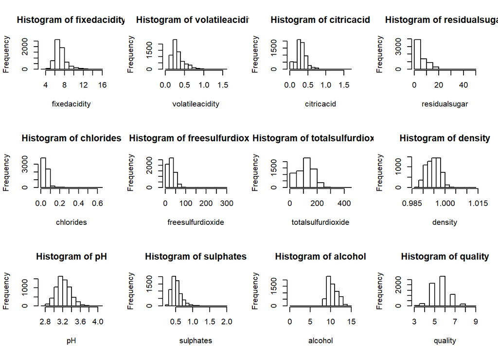

```r
par (mfrow=c(3,4))
attach(Vinhos)
hist(fixedacidity)
hist(volatileacidity)
hist(citricacid )
hist(residualsugar)
hist(chlorides)
hist(freesulfurdioxide)
hist(totalsulfurdioxide)
hist(density)
hist(pH)
hist(sulphates)
hist(alcohol)
hist(quality)
```

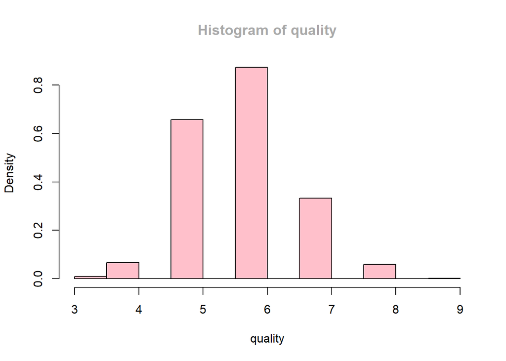

```r
hist(quality, col=c("pink"), col.main="darkgray", prob=T)
```

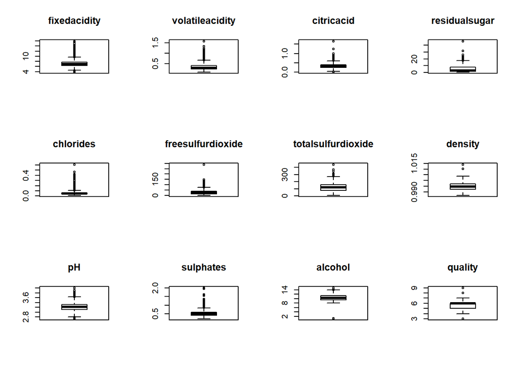

```r
par (mfrow=c(3,4))
boxplot(fixedacidity, main='fixedacidity')
boxplot(volatileacidity , main='volatileacidity')
boxplot(citricacid , main='citricacid')
boxplot(residualsugar, main='residualsugar')
boxplot(chlorides, main='chlorides')
boxplot(freesulfurdioxide, main='freesulfurdioxide')
boxplot(totalsulfurdioxide, main='totalsulfurdioxide')
boxplot(density, main='density')
boxplot(pH, main='pH')
boxplot(sulphates, main='sulphates')
boxplot(alcohol, main='alcohol')
boxplot(Vinhos$quality, main='quality')
```

```r
par (mfrow=c(1,1))
```

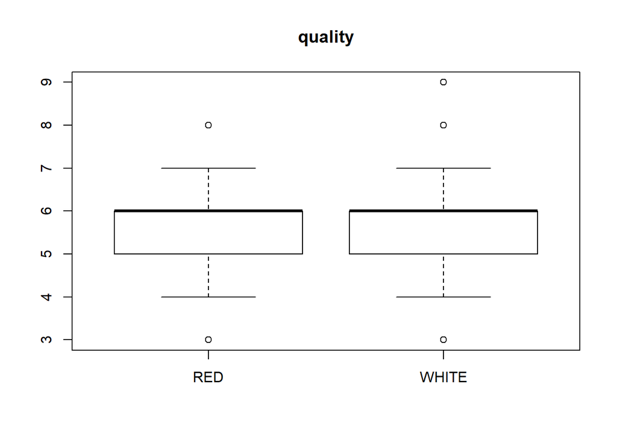

```r
boxplot(quality ~ Vinho, main='quality')
```

## BOXPLOT DE COMPARAÇÃO ENTRE O VINHO RED E WHITE

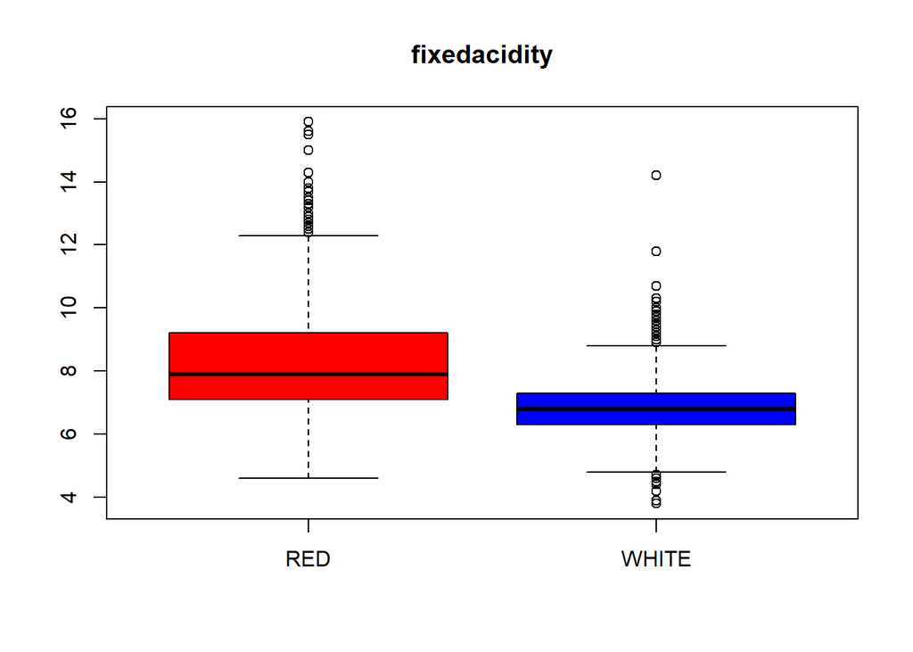

```r
boxplot(fixedacidity ~ Vinho, main='fixedacidity',col=c('red','blue'))
```

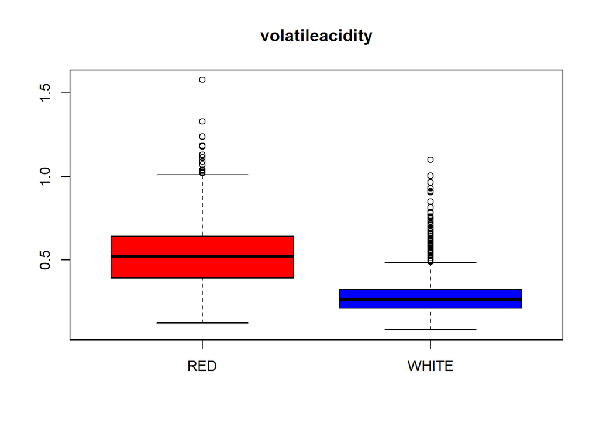

```r
boxplot(volatileacidity ~ Vinho , main='volatileacidity',col=c('red','blue'))
```

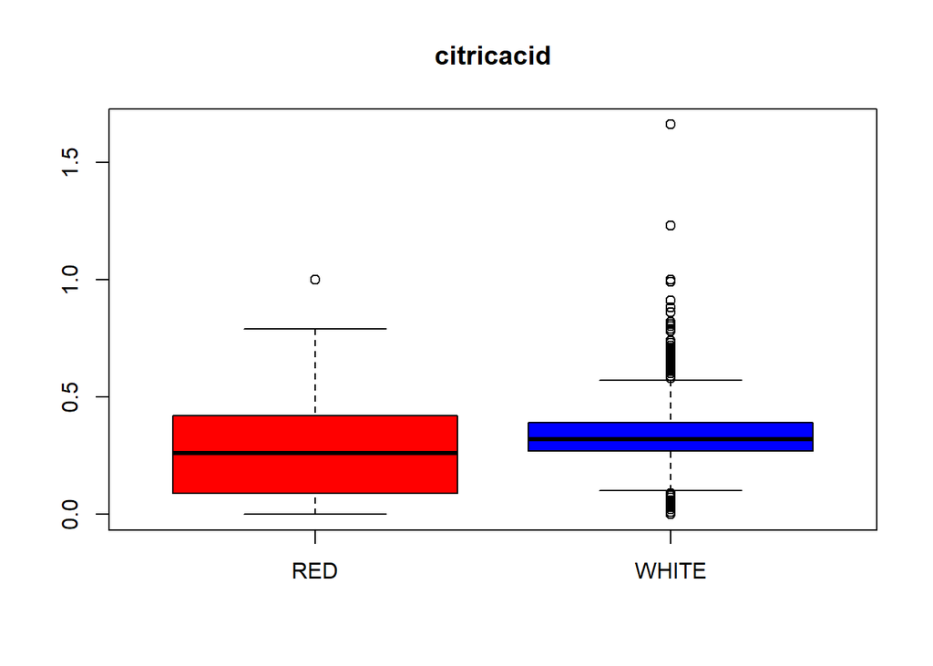

```r
boxplot(citricacid ~ Vinho, main='citricacid',col=c('red','blue'))
```

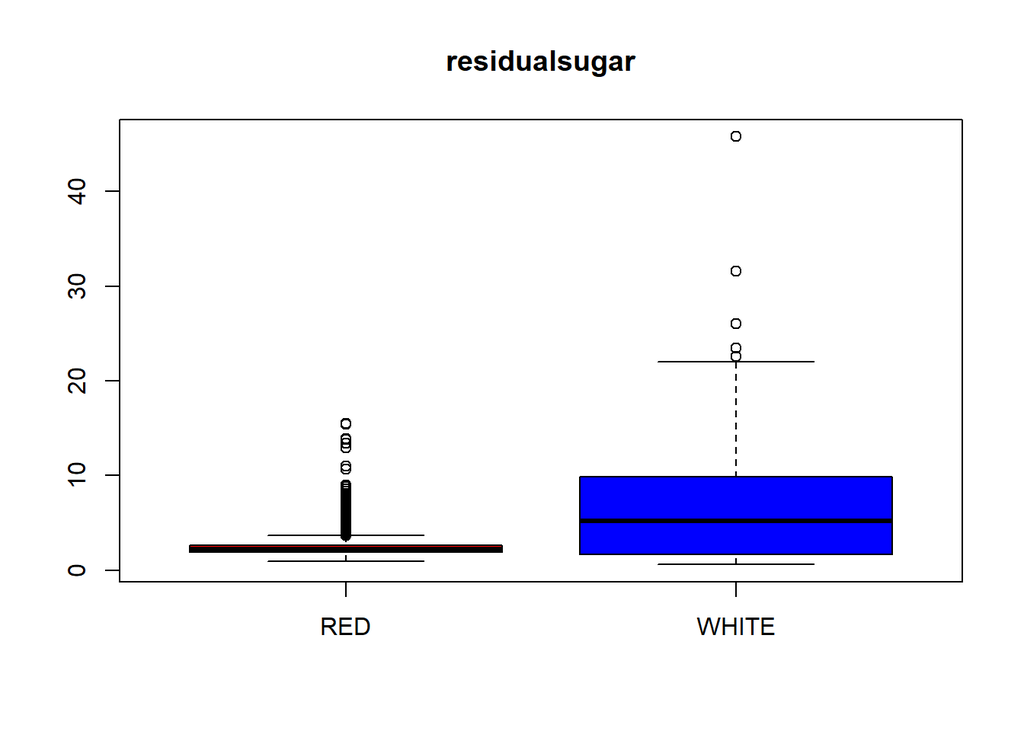

```r
boxplot(residualsugar ~ Vinho, main='residualsugar',col=c('red','blue'))
```

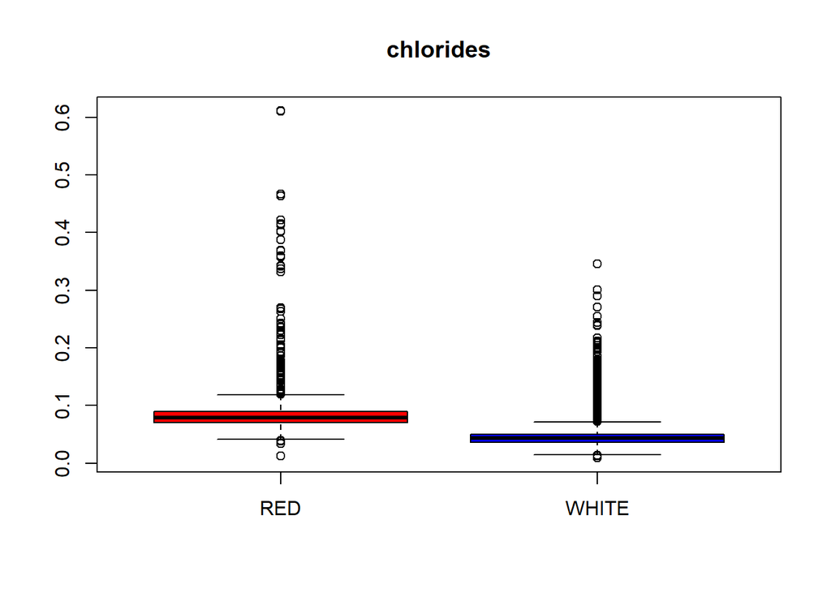

```r
boxplot(chlorides ~ Vinho, main='chlorides',col=c('red','blue'))
```

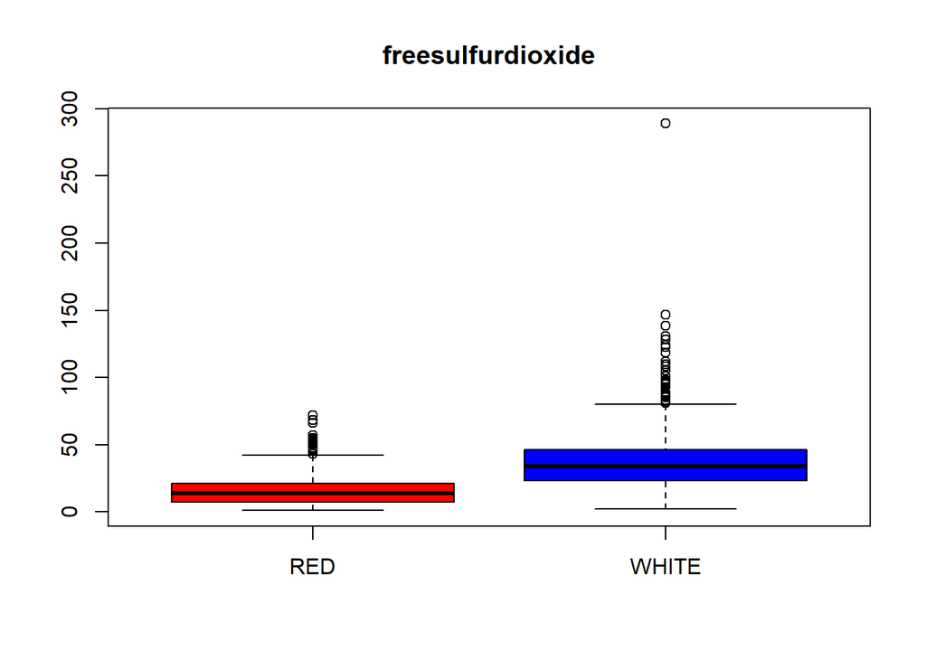

```r
boxplot(freesulfurdioxide ~ Vinho, main='freesulfurdioxide' ,col=c('red','blue'))
```

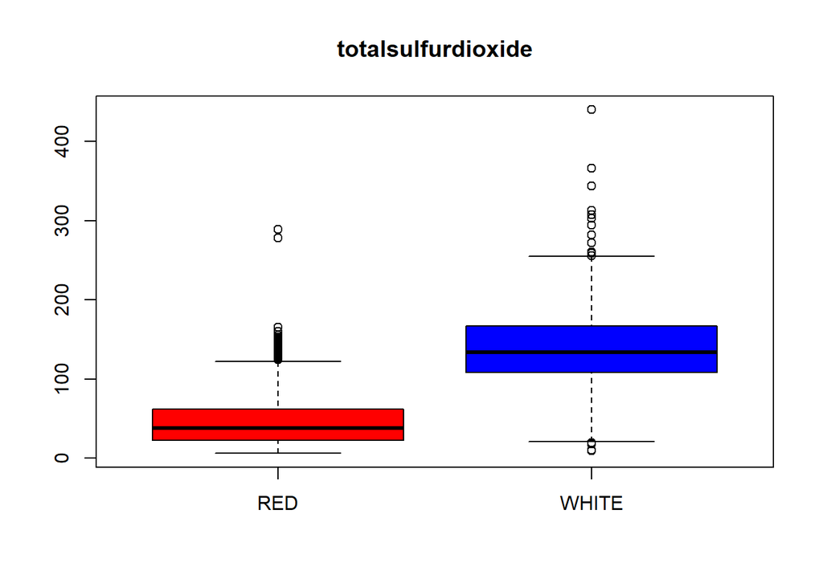

```r
boxplot(totalsulfurdioxide ~ Vinho, main='totalsulfurdioxide',col=c('red','blue'))
```

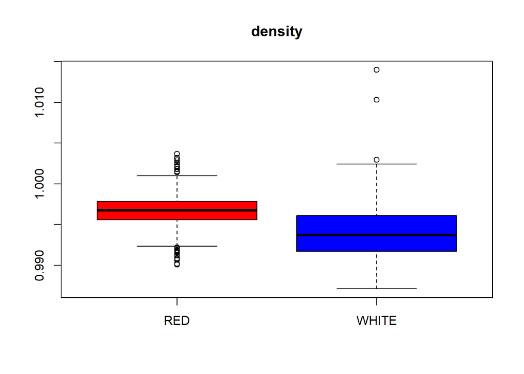

```r
boxplot(density ~ Vinho, main='density',col=c('red','blue'))
```

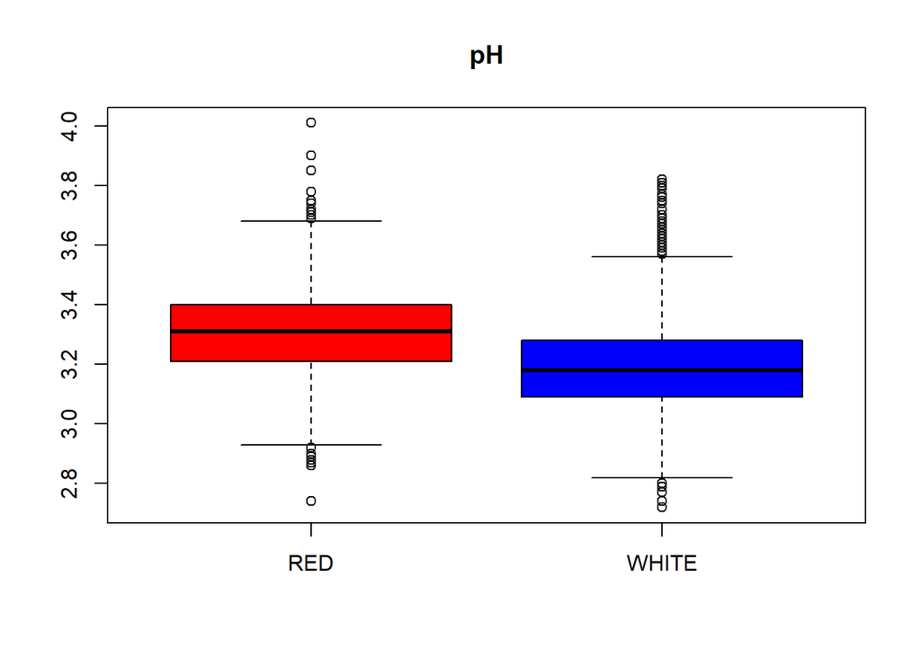

```r
boxplot(pH ~ Vinho, main='pH',col=c('red','blue'))
```

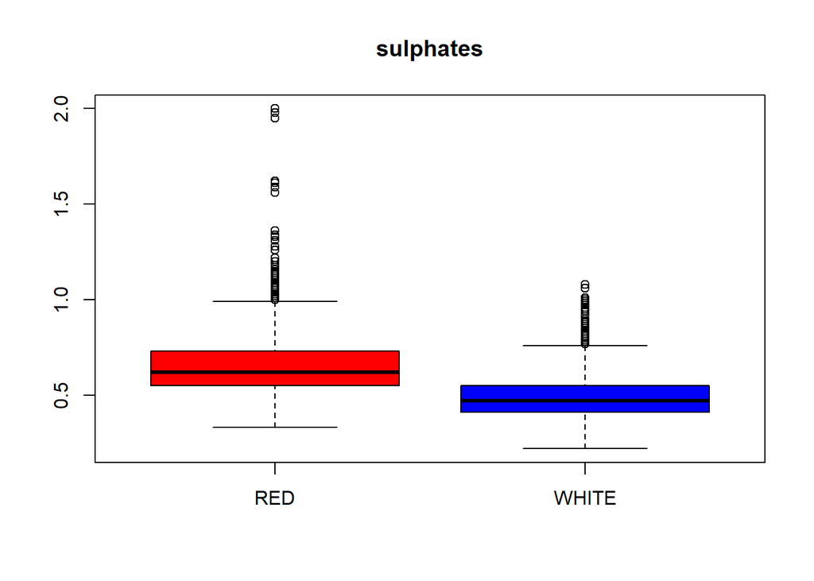

```r
boxplot(sulphates ~ Vinho, main='sulphates',col=c('red','blue'))
```

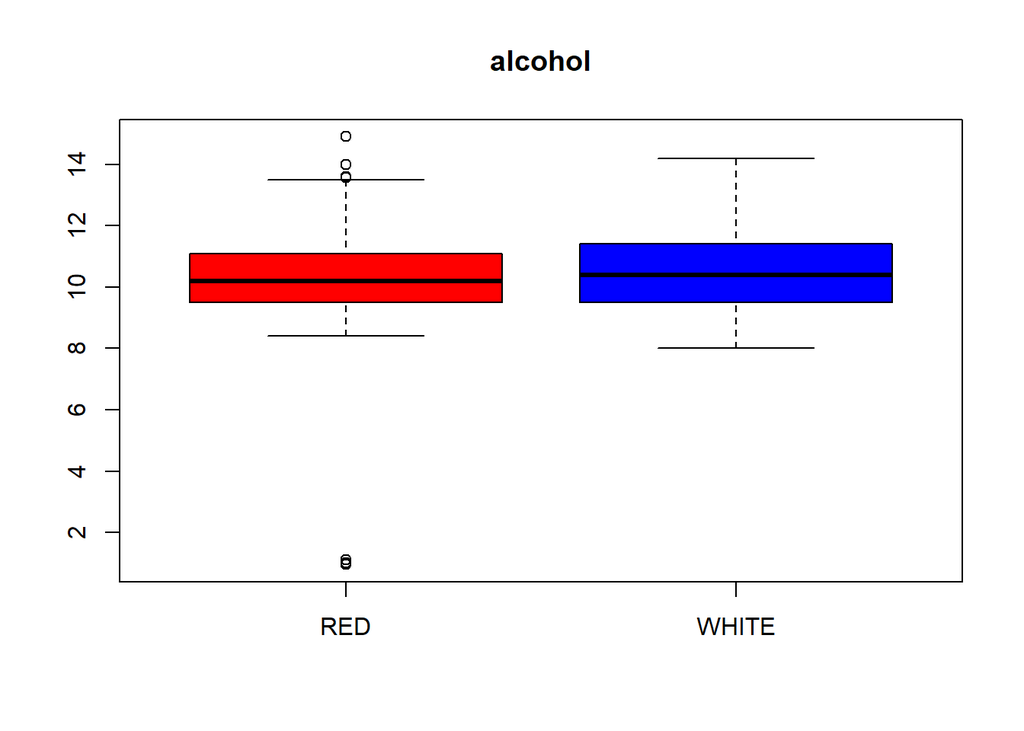

```r
boxplot(alcohol ~ Vinho, main='alcohol',col=c('red','blue'))
```

```r
par (mfrow=c(1,1))
```

## Gráfico de dispersão ( pch=caracter, lwd=largura)

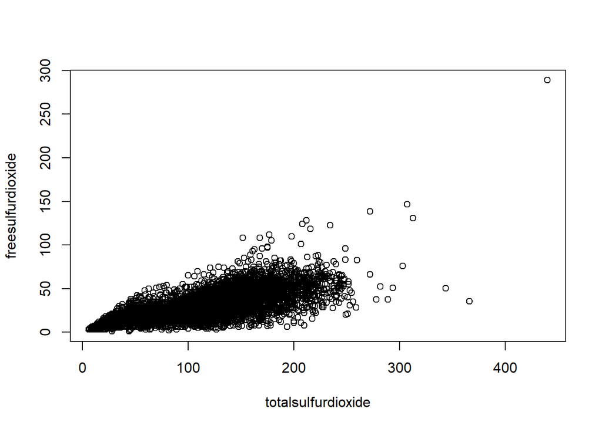

```r
plot(freesulfurdioxide~totalsulfurdioxide)
```

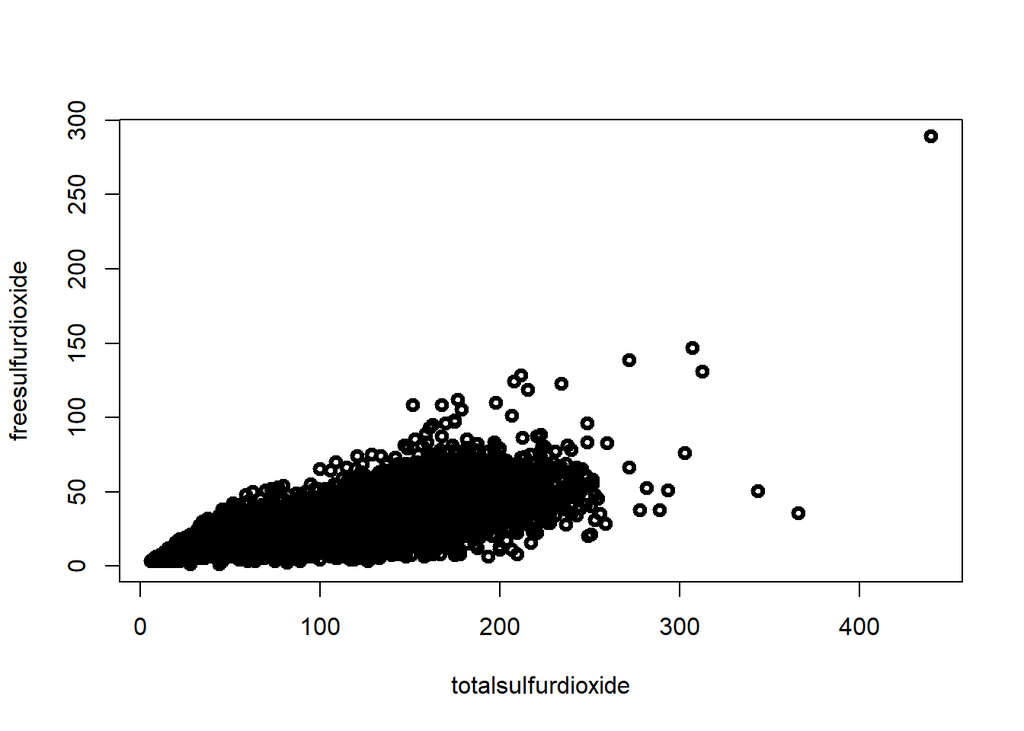

```r
plot(freesulfurdioxide~totalsulfurdioxide, pch=1, lwd=3)
```

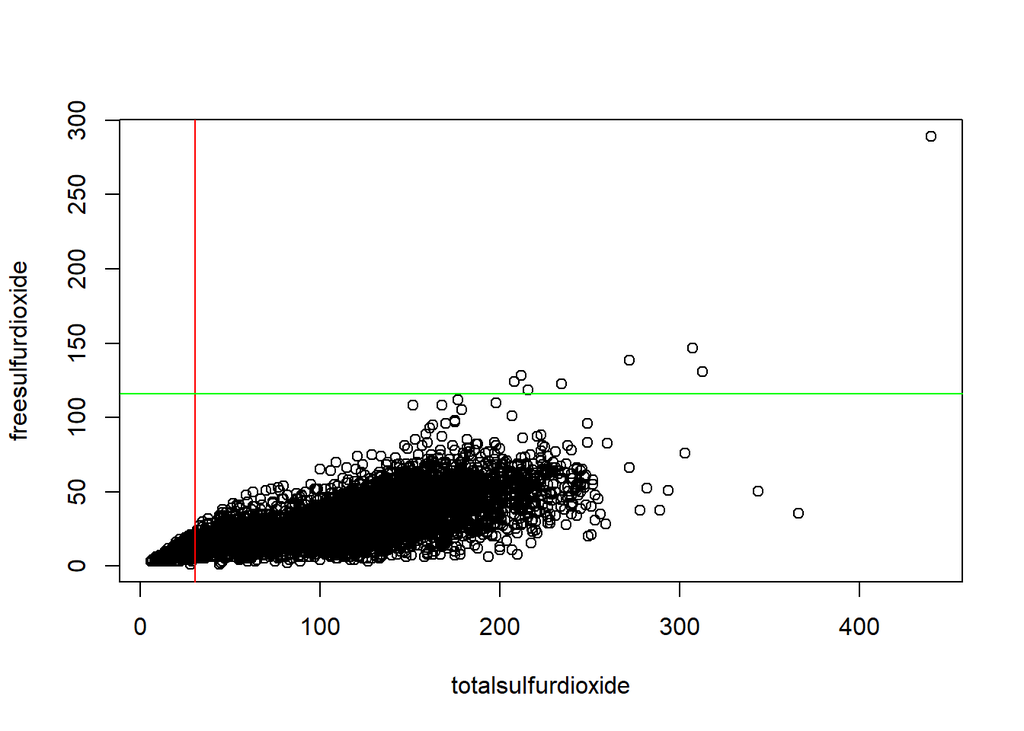

```r
plot(freesulfurdioxide~totalsulfurdioxide)
abline(v=mean(freesulfurdioxide), col="red")
abline(h=mean(totalsulfurdioxide), col="green")
```

Nesse Crosstable foi feito um crosstable entre os vinhos Red e White e o açucar residual dividido em quatro concentrações. O que podemos ver é que o vinho Red é onde eu tenho os vinhos com menor concentração de residuos de açucar.

```r
Vinhos$fx_redSugar <- cut(residualsugar,breaks=c(0,10,20,30,max(residualsugar)))
head(Vinhos$fx_redSugar, 10)
```

```
##  [1] (0,10]  (0,10]  (0,10]  (0,10]  (10,20] (0,10]  (0,10]  (0,10]
##  [9] (0,10]  (20,30]
## Levels: (0,10] (10,20] (20,30] (30,45.8]
```

```r
str(Vinhos)
```

```
## 'data.frame':    6497 obs. of  14 variables:
##  $ fixedacidity      : num  6.6 6.7 10.6 5.4 6.7 6.8 6.6 7.2 5.1 6.2 ...
##  $ volatileacidity   : num  0.24 0.34 0.31 0.18 0.3 0.5 0.61 0.66 0.26 0.22 ...
##  $ citricacid        : num  0.35 0.43 0.49 0.24 0.44 0.11 0 0.33 0.33 0.2 ...
##  $ residualsugar     : num  7.7 1.6 2.2 4.8 18.8 ...
##  $ chlorides         : num  0.031 0.041 0.063 0.041 0.057 0.075 0.069 0.068 0.027 0.035 ...
##  $ freesulfurdioxide : num  36 29 18 30 65 16 4 34 46 58 ...
##  $ totalsulfurdioxide: num  135 114 40 113 224 49 8 102 113 184 ...
##  $ density           : num  0.994 0.99 0.998 0.994 1 ...
##  $ pH                : num  3.19 3.23 3.14 3.42 3.11 3.36 3.33 3.27 3.35 3.11 ...
##  $ sulphates         : num  0.37 0.44 0.51 0.4 0.53 0.79 0.37 0.78 0.43 0.53 ...
##  $ alcohol           : num  10.5 12.6 9.8 9.4 9.1 9.5 10.4 12.8 11.4 9 ...
##  $ quality           : num  5 6 6 6 5 5 4 6 7 6 ...
##  $ Vinho             : Factor w/ 2 levels "RED","WHITE": 2 2 1 2 2 1 1 1 2 2 ...
##  $ fx_redSugar       : Factor w/ 4 levels "(0,10]","(10,20]",..: 1 1 1 1 2 1 1 1 1 3 ...
```

```r
CrossTable( Vinhos$fx_redSugar , Vinhos$Vinho)
```

```
##
##
##    Cell Contents
## |-------------------------|
## |                       N |
## | Chi-square contribution |
## |           N / Row Total |
## |           N / Col Total |
## |         N / Table Total |
## |-------------------------|
##
##
## Total Observations in Table:  6497
##
##
##                    | Vinhos$Vinho
## Vinhos$fx_redSugar |       RED |     WHITE | Row Total |
## -------------------|-----------|-----------|-----------|
##             (0,10] |      1588 |      3705 |      5293 |
##                    |    62.493 |    20.401 |           |
##                    |     0.300 |     0.700 |     0.815 |
##                    |     0.993 |     0.756 |           |
##                    |     0.244 |     0.570 |           |
## -------------------|-----------|-----------|-----------|
##            (10,20] |        11 |      1175 |      1186 |
##                    |   270.305 |    88.244 |           |
##                    |     0.009 |     0.991 |     0.183 |
##                    |     0.007 |     0.240 |           |
##                    |     0.002 |     0.181 |           |
## -------------------|-----------|-----------|-----------|
##            (20,30] |         0 |        15 |        15 |
##                    |     3.692 |     1.205 |           |
##                    |     0.000 |     1.000 |     0.002 |
##                    |     0.000 |     0.003 |           |
##                    |     0.000 |     0.002 |           |
## -------------------|-----------|-----------|-----------|
##          (30,45.8] |         0 |         3 |         3 |
##                    |     0.738 |     0.241 |           |
##                    |     0.000 |     1.000 |     0.000 |
##                    |     0.000 |     0.001 |           |
##                    |     0.000 |     0.000 |           |
## -------------------|-----------|-----------|-----------|
##       Column Total |      1599 |      4898 |      6497 |
##                    |     0.246 |     0.754 |           |
## -------------------|-----------|-----------|-----------|
##
##
```

Nesse momento vamos analisar somente o vinho White pois, nele temos mais dados e com isso futuramente conseguimos fazer modelos mais acertivos.

```r
white <- subset(Vinhos, Vinho=="WHITE", select=c(quality,fixedacidity,volatileacidity,citricacid,residualsugar,
                                                 chlorides,freesulfurdioxide,totalsulfurdioxide,density,pH,
                                                 sulphates,alcohol))
```

## Estatísticas descritivas

Fazendo uma analise da base completa e com vinhos White, podemos ver que não vamos perder informações pois no summary os valores são bem parecidos e não corremos o risco de “influenciar” nossos futuros algoritimos de treino.

```r
summary(white)
```

```
##     quality       fixedacidity    volatileacidity    citricacid
##  Min.   :3.000   Min.   : 3.800   Min.   :0.0800   Min.   :0.0000
##  1st Qu.:5.000   1st Qu.: 6.300   1st Qu.:0.2100   1st Qu.:0.2700
##  Median :6.000   Median : 6.800   Median :0.2600   Median :0.3200
##  Mean   :5.878   Mean   : 6.855   Mean   :0.2782   Mean   :0.3342
##  3rd Qu.:6.000   3rd Qu.: 7.300   3rd Qu.:0.3200   3rd Qu.:0.3900
##  Max.   :9.000   Max.   :14.200   Max.   :1.1000   Max.   :1.6600
##  residualsugar      chlorides       freesulfurdioxide totalsulfurdioxide
##  Min.   : 0.600   Min.   :0.00900   Min.   :  2.00    Min.   :  9.0
##  1st Qu.: 1.700   1st Qu.:0.03600   1st Qu.: 23.00    1st Qu.:108.0
##  Median : 5.200   Median :0.04300   Median : 34.00    Median :134.0
##  Mean   : 6.387   Mean   :0.04577   Mean   : 35.31    Mean   :138.4
##  3rd Qu.: 9.900   3rd Qu.:0.05000   3rd Qu.: 46.00    3rd Qu.:167.0
##  Max.   :45.800   Max.   :0.34600   Max.   :289.00    Max.   :440.0
##     density             pH          sulphates         alcohol
##  Min.   :0.9871   Min.   :2.720   Min.   :0.2200   Min.   : 8.00
##  1st Qu.:0.9917   1st Qu.:3.090   1st Qu.:0.4100   1st Qu.: 9.50
##  Median :0.9937   Median :3.180   Median :0.4700   Median :10.40
##  Mean   :0.9940   Mean   :3.188   Mean   :0.4898   Mean   :10.51
##  3rd Qu.:0.9961   3rd Qu.:3.280   3rd Qu.:0.5500   3rd Qu.:11.40
##  Max.   :1.0140   Max.   :3.820   Max.   :1.0800   Max.   :14.20
```

```r
summary(Vinhos)
```

```
##   fixedacidity    volatileacidity    citricacid     residualsugar
##  Min.   : 3.800   Min.   :0.0800   Min.   :0.0000   Min.   : 0.60
##  1st Qu.: 6.400   1st Qu.:0.2300   1st Qu.:0.2500   1st Qu.: 1.80
##  Median : 7.000   Median :0.2900   Median :0.3100   Median : 3.00
##  Mean   : 7.215   Mean   :0.3397   Mean   :0.3186   Mean   : 5.44
##  3rd Qu.: 7.700   3rd Qu.:0.4000   3rd Qu.:0.3900   3rd Qu.: 8.10
##  Max.   :15.900   Max.   :1.5800   Max.   :1.6600   Max.   :45.80
##    chlorides       freesulfurdioxide totalsulfurdioxide    density
##  Min.   :0.00900   Min.   :  1.00    Min.   :  6.0      Min.   :0.9871
##  1st Qu.:0.03800   1st Qu.: 17.00    1st Qu.: 77.0      1st Qu.:0.9923
##  Median :0.04700   Median : 29.00    Median :118.0      Median :0.9949
##  Mean   :0.05603   Mean   : 30.53    Mean   :115.7      Mean   :0.9947
##  3rd Qu.:0.06500   3rd Qu.: 41.00    3rd Qu.:156.0      3rd Qu.:0.9970
##  Max.   :0.61100   Max.   :289.00    Max.   :440.0      Max.   :1.0140
##        pH          sulphates         alcohol           quality
##  Min.   :2.720   Min.   :0.2200   Min.   : 0.9567   Min.   :3.000
##  1st Qu.:3.110   1st Qu.:0.4300   1st Qu.: 9.5000   1st Qu.:5.000
##  Median :3.210   Median :0.5100   Median :10.3000   Median :6.000
##  Mean   :3.219   Mean   :0.5313   Mean   :10.4862   Mean   :5.818
##  3rd Qu.:3.320   3rd Qu.:0.6000   3rd Qu.:11.3000   3rd Qu.:6.000
##  Max.   :4.010   Max.   :2.0000   Max.   :14.9000   Max.   :9.000
##    Vinho         fx_redSugar
##  RED  :1599   (0,10]   :5293
##  WHITE:4898   (10,20]  :1186
##               (20,30]  :  15
##               (30,45.8]:   3
##
##
```

```r
str(white)
```

```
## 'data.frame':    4898 obs. of  12 variables:
##  $ quality           : num  5 6 6 5 7 6 5 6 6 6 ...
##  $ fixedacidity      : num  6.6 6.7 5.4 6.7 5.1 6.2 6.6 7.3 6.7 6.2 ...
##  $ volatileacidity   : num  0.24 0.34 0.18 0.3 0.26 0.22 0.25 0.27 0.26 0.12 ...
##  $ citricacid        : num  0.35 0.43 0.24 0.44 0.33 0.2 0.36 0.37 0.29 0.26 ...
##  $ residualsugar     : num  7.7 1.6 4.8 18.8 1.1 ...
##  $ chlorides         : num  0.031 0.041 0.041 0.057 0.027 0.035 0.045 0.042 0.038 0.044 ...
##  $ freesulfurdioxide : num  36 29 30 65 46 58 54 36 40 56 ...
##  $ totalsulfurdioxide: num  135 114 113 224 113 184 180 130 179 158 ...
##  $ density           : num  0.994 0.99 0.994 1 0.989 ...
##  $ pH                : num  3.19 3.23 3.42 3.11 3.35 3.11 3.08 3.48 3.23 3.52 ...
##  $ sulphates         : num  0.37 0.44 0.4 0.53 0.43 0.53 0.42 0.75 0.56 0.37 ...
##  $ alcohol           : num  10.5 12.6 9.4 9.1 11.4 9 9.2 9.9 10.4 10.5 ...
```

```r
attach(white)
```

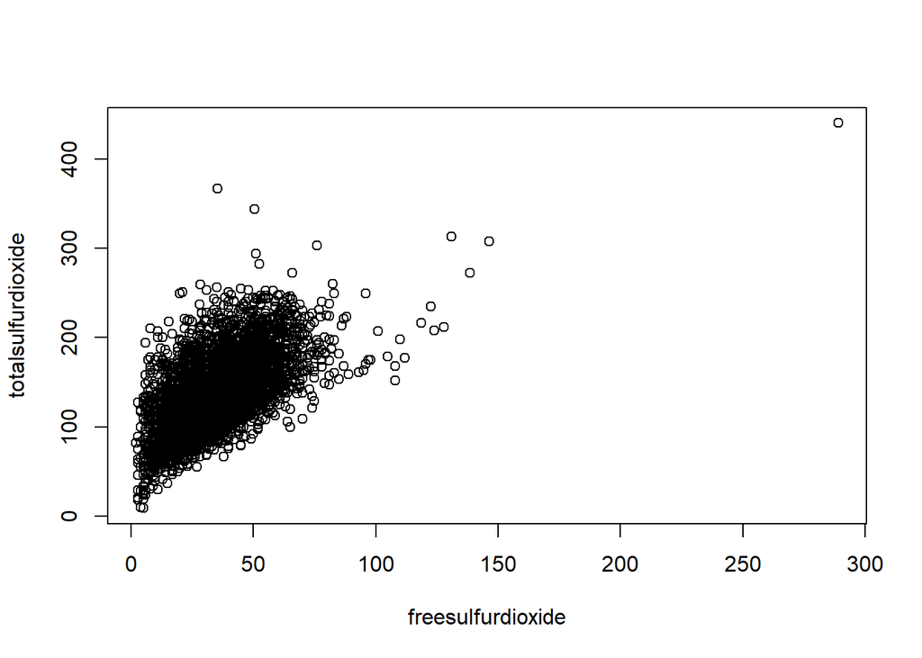

```r
plot(freesulfurdioxide, totalsulfurdioxide)
```

## Estatísticas descritivas

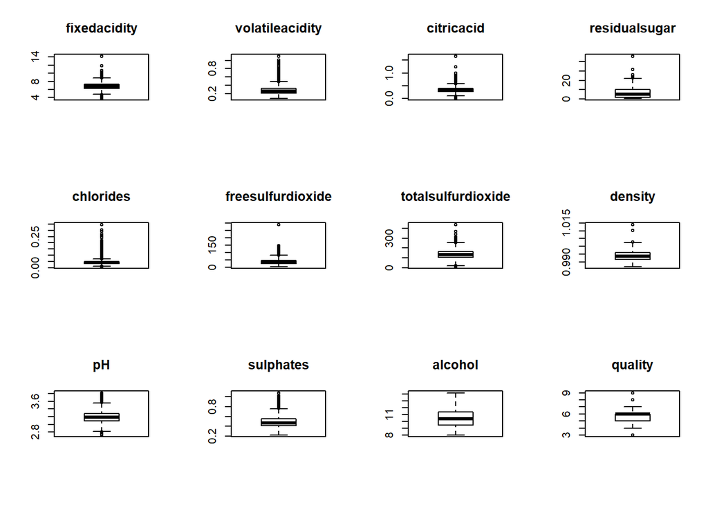

```r
par (mfrow=c(3,4))
boxplot(fixedacidity, main='fixedacidity')
boxplot(volatileacidity , main='volatileacidity')
boxplot(citricacid , main='citricacid')
boxplot(residualsugar, main='residualsugar')
boxplot(chlorides, main='chlorides')
boxplot(freesulfurdioxide, main='freesulfurdioxide')
boxplot(totalsulfurdioxide, main='totalsulfurdioxide')
boxplot(density, main='density')
boxplot(pH, main='pH')
boxplot(sulphates, main='sulphates')
boxplot(alcohol, main='alcohol')
boxplot(quality, main='quality')
```

```r
par (mfrow=c(1,1))
```

```r
boxplot.stats(white$residualsugar)
```

```
## $stats
## [1]  0.6  1.7  5.2  9.9 22.0
##
## $n
## [1] 4898
##
## $conf
## [1] 5.014877 5.385123
##
## $out
## [1] 26.05 31.60 22.60 45.80 31.60 26.05 23.50
```

```r
boxplot.stats(white$density)
```

```
## $stats
## [1] 0.98711 0.99172 0.99374 0.99610 1.00241
##
## $n
## [1] 4898
##
## $conf
## [1] 0.9936411 0.9938389
##
## $out
## [1] 1.00295 1.01030 1.01398 1.01030 1.00295
```

```r
boxplot.stats(white$volatileacidity)
```

```
## $stats
## [1] 0.080 0.210 0.260 0.320 0.485
##
## $n
## [1] 4898
##
## $conf
## [1] 0.2575166 0.2624834
##
## $out
##   [1] 0.580 0.560 0.510 0.520 0.695 0.670 0.550 0.610 0.640 0.710 0.640
##  [12] 0.555 0.540 0.570 0.510 0.520 0.660 0.610 0.595 0.520 0.620 0.580
##  [23] 0.490 0.530 0.550 0.520 0.590 0.570 0.510 0.490 0.550 0.560 0.540
##  [34] 0.590 0.910 0.660 0.510 0.550 0.640 0.690 0.670 0.510 0.490 0.540
##  [45] 0.690 0.580 0.555 0.580 0.600 0.545 0.500 0.610 0.670 0.815 0.650
##  [56] 0.530 0.540 0.655 0.600 0.520 0.550 0.560 0.670 0.655 0.500 0.520
##  [67] 0.680 0.615 0.490 0.560 0.550 0.490 0.930 0.490 0.685 0.520 0.530
##  [78] 0.550 0.760 0.640 0.490 0.560 0.600 0.510 0.580 0.640 0.620 1.005
##  [89] 0.560 0.965 0.520 0.500 0.520 0.490 0.560 0.540 0.500 0.530 0.520
## [100] 0.640 0.640 0.600 0.530 0.490 0.530 0.695 0.560 0.610 0.500 0.500
## [111] 0.730 0.500 0.510 0.660 0.600 0.670 0.580 0.780 0.680 0.630 0.615
## [122] 0.530 0.615 0.620 0.500 0.570 0.540 0.490 0.550 0.550 0.500 0.530
## [133] 0.550 0.785 0.570 1.100 0.705 0.600 0.850 0.510 0.500 0.600 0.495
## [144] 0.620 0.660 0.750 0.540 0.905 0.490 0.550 0.510 0.655 0.585 0.705
## [155] 0.680 0.580 0.500 0.540 0.595 0.610 0.540 0.500 0.650 0.610 0.615
## [166] 0.740 0.610 0.495 0.550 0.585 0.590 0.760 0.490 0.510 0.695 0.500
## [177] 0.620 0.540 0.550 0.490 0.630 0.590 0.550 0.490 0.560 0.500
```

```r
quantile(residualsugar,.75,type=4)
```

```
## 75%
## 9.9
```

```r
quantile(residualsugar,.25,type=2)
```

```
## 25%
## 1.7
```

```r
AIQ_residualsugar<-quantile(residualsugar,.75,type=4)-quantile(residualsugar,.25,type=2)
AIQ_residualsugar
```

```
## 75%
## 8.2
```

```r
limsup_residualsugar<- quantile(residualsugar,.75,type=4)+1.5*AIQ_residualsugar
liminf_residualsugar<- quantile(residualsugar,.25,type=2)-1.5*AIQ_residualsugar
limsup_residualsugar
```

```
##  75%
## 22.2
```

```r
liminf_residualsugar
```

```
##   25%
## -10.6
```

## Mudança na base

```r
white<-white %>%
      mutate(outl_sugar= if_else(residualsugar<liminf_residualsugar | residualsugar>limsup_residualsugar,1,0))
table(white$outl_sugar)
```

```
##
##    0    1
## 4891    7
```

```r
white1<-subset(white, residualsugar<=40)

white1 <- subset(white, select=c(quality,fixedacidity,volatileacidity,citricacid,residualsugar,
                                                 chlorides,freesulfurdioxide,totalsulfurdioxide,density,pH,
                                                 sulphates,alcohol))
summary(white1)
```

```
##     quality       fixedacidity    volatileacidity    citricacid
##  Min.   :3.000   Min.   : 3.800   Min.   :0.0800   Min.   :0.0000
##  1st Qu.:5.000   1st Qu.: 6.300   1st Qu.:0.2100   1st Qu.:0.2700
##  Median :6.000   Median : 6.800   Median :0.2600   Median :0.3200
##  Mean   :5.878   Mean   : 6.855   Mean   :0.2782   Mean   :0.3342
##  3rd Qu.:6.000   3rd Qu.: 7.300   3rd Qu.:0.3200   3rd Qu.:0.3900
##  Max.   :9.000   Max.   :14.200   Max.   :1.1000   Max.   :1.6600
##  residualsugar      chlorides       freesulfurdioxide totalsulfurdioxide
##  Min.   : 0.600   Min.   :0.00900   Min.   :  2.00    Min.   :  9.0
##  1st Qu.: 1.700   1st Qu.:0.03600   1st Qu.: 23.00    1st Qu.:108.0
##  Median : 5.200   Median :0.04300   Median : 34.00    Median :134.0
##  Mean   : 6.387   Mean   :0.04577   Mean   : 35.31    Mean   :138.4
##  3rd Qu.: 9.900   3rd Qu.:0.05000   3rd Qu.: 46.00    3rd Qu.:167.0
##  Max.   :45.800   Max.   :0.34600   Max.   :289.00    Max.   :440.0
##     density             pH          sulphates         alcohol
##  Min.   :0.9871   Min.   :2.720   Min.   :0.2200   Min.   : 8.00
##  1st Qu.:0.9917   1st Qu.:3.090   1st Qu.:0.4100   1st Qu.: 9.50
##  Median :0.9937   Median :3.180   Median :0.4700   Median :10.40
##  Mean   :0.9940   Mean   :3.188   Mean   :0.4898   Mean   :10.51
##  3rd Qu.:0.9961   3rd Qu.:3.280   3rd Qu.:0.5500   3rd Qu.:11.40
##  Max.   :1.0140   Max.   :3.820   Max.   :1.0800   Max.   :14.20
```

## matriz de correlações

Este grafico comprova todas as analises feitas acima.

```r
matcor <- round(cor(white1),3)
print(matcor  )
```

```
##                    quality fixedacidity volatileacidity citricacid
## quality              1.000       -0.114          -0.195     -0.009
## fixedacidity        -0.114        1.000          -0.023      0.289
## volatileacidity     -0.195       -0.023           1.000     -0.149
## citricacid          -0.009        0.289          -0.149      1.000
## residualsugar       -0.098        0.089           0.059      0.093
## chlorides           -0.210        0.023           0.071      0.114
## freesulfurdioxide    0.008       -0.049          -0.097      0.094
## totalsulfurdioxide  -0.175        0.091           0.089      0.121
## density             -0.313        0.268           0.016      0.149
## pH                   0.099       -0.426          -0.032     -0.164
## sulphates            0.054       -0.017          -0.036      0.062
## alcohol              0.436       -0.121           0.068     -0.076
##                    residualsugar chlorides freesulfurdioxide
## quality                   -0.098    -0.210             0.008
## fixedacidity               0.089     0.023            -0.049
## volatileacidity            0.059     0.071            -0.097
## citricacid                 0.093     0.114             0.094
## residualsugar              1.000     0.088             0.303
## chlorides                  0.088     1.000             0.101
## freesulfurdioxide          0.303     0.101             1.000
## totalsulfurdioxide         0.404     0.199             0.616
## density                    0.836     0.260             0.303
## pH                        -0.197    -0.090            -0.001
## sulphates                 -0.028     0.017             0.059
## alcohol                   -0.455    -0.360            -0.250
##                    totalsulfurdioxide density     pH sulphates alcohol
## quality                        -0.175  -0.313  0.099     0.054   0.436
## fixedacidity                    0.091   0.268 -0.426    -0.017  -0.121
## volatileacidity                 0.089   0.016 -0.032    -0.036   0.068
## citricacid                      0.121   0.149 -0.164     0.062  -0.076
## residualsugar                   0.404   0.836 -0.197    -0.028  -0.455
## chlorides                       0.199   0.260 -0.090     0.017  -0.360
## freesulfurdioxide               0.616   0.303 -0.001     0.059  -0.250
## totalsulfurdioxide              1.000   0.539  0.002     0.135  -0.449
## density                         0.539   1.000 -0.098     0.073  -0.797
## pH                              0.002  -0.098  1.000     0.156   0.121
## sulphates                       0.135   0.073  0.156     1.000  -0.017
## alcohol                        -0.449  -0.797  0.121    -0.017   1.000
```

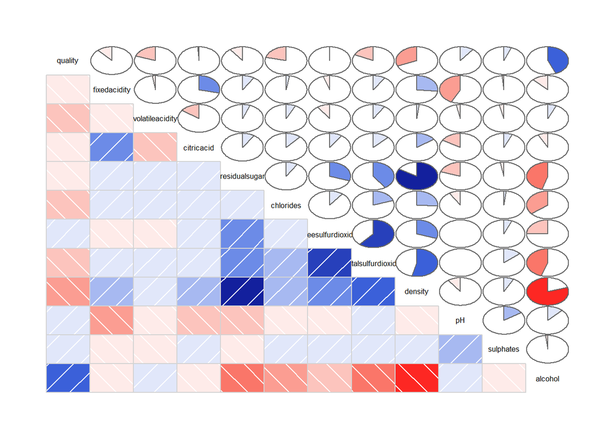

```r
corrgram(matcor, type = "cor", lower.panel = panel.shade, upper.panel = panel.pie)
```

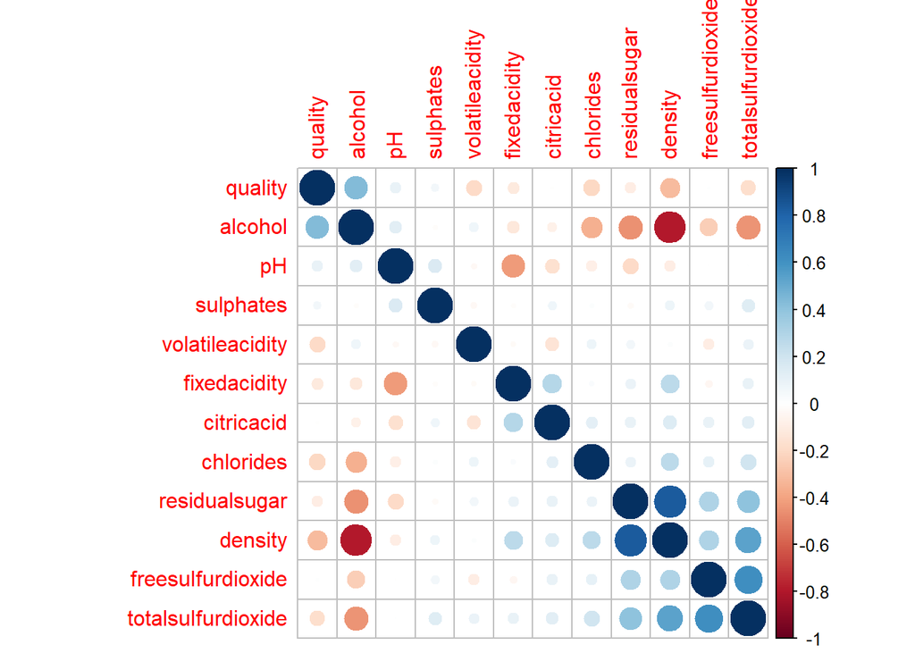

```r
corrplot::corrplot(matcor, method="circle", order="hclust")
```

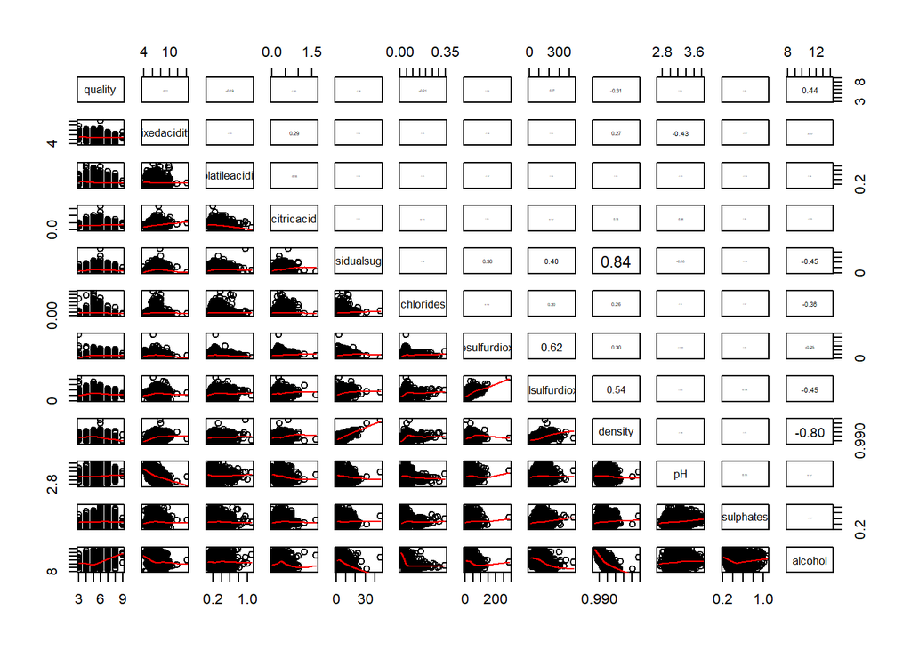

```r
panel.cor <- function(x, y, digits=2, prefix ="", cex.cor,
                      ...)  {
  usr <- par("usr")
  on.exit(par(usr))
  par(usr = c(0, 1, 0, 1))
  r <- cor(x, y , use = "pairwise.complete.obs")
  txt <- format(c(r, 0.123456789), digits = digits) [1]
  txt <- paste(prefix, txt, sep = "")
  if (missing(cex.cor))
    cex <- 0.8/strwidth(txt)
  # abs(r) Ã© para que na saÃ?da as correlaÃ§Ãµes ficam proporcionais
  text(0.5, 0.5, txt, cex = cex * abs(r))
}
pairs(white1, lower.panel=panel.smooth, upper.panel=panel.cor)
```

```r
white2 <- subset(white1, select=c(-quality))
```

## Avaliar inicio

Aqui utilizamos uma função genérica cujo método padrão centraliza e / ou dimensiona as colunas de uma matriz numérica.

```r
vinhos_padroniz = as.data.frame(scale(white2))
names(vinhos_padroniz)
```

```
##  [1] "fixedacidity"       "volatileacidity"    "citricacid"
##  [4] "residualsugar"      "chlorides"          "freesulfurdioxide"
##  [7] "totalsulfurdioxide" "density"            "pH"
## [10] "sulphates"          "alcohol"
```

```r
summary(vinhos_padroniz)
```

```
##   fixedacidity      volatileacidity     citricacid      residualsugar
##  Min.   :-3.61998   Min.   :-1.9668   Min.   :-2.7615   Min.   :-1.1501
##  1st Qu.:-0.65743   1st Qu.:-0.6770   1st Qu.:-0.5304   1st Qu.:-0.9315
##  Median :-0.06492   Median :-0.1810   Median :-0.1173   Median :-0.2360
##  Mean   : 0.00000   Mean   : 0.0000   Mean   : 0.0000   Mean   : 0.0000
##  3rd Qu.: 0.52758   3rd Qu.: 0.4143   3rd Qu.: 0.4612   3rd Qu.: 0.6980
##  Max.   : 8.70422   Max.   : 8.1528   Max.   :10.9553   Max.   : 7.8322
##    chlorides       freesulfurdioxide  totalsulfurdioxide
##  Min.   :-1.6831   Min.   :-1.95848   Min.   :-3.0439
##  1st Qu.:-0.4473   1st Qu.:-0.72370   1st Qu.:-0.7144
##  Median :-0.1269   Median :-0.07691   Median :-0.1026
##  Mean   : 0.0000   Mean   : 0.00000   Mean   : 0.0000
##  3rd Qu.: 0.1935   3rd Qu.: 0.62867   3rd Qu.: 0.6739
##  Max.   :13.7417   Max.   :14.91679   Max.   : 7.0977
##     density               pH             sulphates
##  Min.   :-2.35513   Min.   :-3.10109   Min.   :-2.3645
##  1st Qu.:-0.78357   1st Qu.:-0.65077   1st Qu.:-0.6996
##  Median :-0.09617   Median :-0.05475   Median :-0.1739
##  Mean   : 0.00000   Mean   : 0.00000   Mean   : 0.0000
##  3rd Qu.: 0.70792   3rd Qu.: 0.60750   3rd Qu.: 0.5271
##  Max.   : 6.79994   Max.   : 4.18365   Max.   : 5.1711
##     alcohol
##  Min.   :-2.04309
##  1st Qu.:-0.82419
##  Median :-0.09285
##  Mean   : 0.00000
##  3rd Qu.: 0.71974
##  Max.   : 2.99502
```

## Componentes Principais - Básico (PCA)

O objetivo é encontrar combinações lineares das variáveis que incluam a maior quantidade possível de variância original.  
Esta transformação é definida de forma que o primeiro componente principal tem a maior variância possível, e cada componente seguinte, por sua vez, tem a máxima variância sob a restrição de ser ortogonal a (i.e., não correlacionado com) os componentes anteriores.  
Quanto maior a dimensão dos dados (número de variáveis) maior o risco de sobre ajuste do modelo.

```r
acpcor <- prcomp(vinhos_padroniz , scale = TRUE)
summary(acpcor)
```

```
## Importance of components:
##                           PC1    PC2    PC3     PC4     PC5     PC6
## Standard deviation     1.7999 1.2551 1.1040 1.01022 0.98743 0.96603
## Proportion of Variance 0.2945 0.1432 0.1108 0.09278 0.08864 0.08484
## Cumulative Proportion  0.2945 0.4377 0.5485 0.64129 0.72993 0.81477
##                            PC7     PC8     PC9    PC10    PC11
## Standard deviation     0.84999 0.77459 0.64068 0.53811 0.12262
## Proportion of Variance 0.06568 0.05454 0.03732 0.02632 0.00137
## Cumulative Proportion  0.88045 0.93499 0.97231 0.99863 1.00000
```

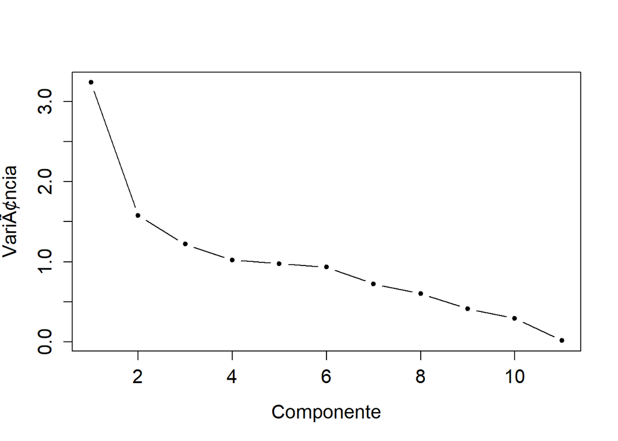

```r
plot(1:ncol(vinhos_padroniz ), acpcor$sdev^2, type = "b", xlab = "Componente",
     ylab = "VariÃ¢ncia", pch = 20, cex.axis = 1.3, cex.lab = 1.3)
```

```r
sum(acpcor$sdev^2)
```

```
## [1] 11
```

```r
acpcor$rotation[, 1:11]
```

```
##                             PC1          PC2        PC3         PC4
## fixedacidity        0.156727731 -0.587654394  0.1222004  0.02553995
## volatileacidity     0.001481749  0.051558154 -0.5879046  0.29587580
## citricacid          0.142692529 -0.345460101  0.5068792  0.15208042
## residualsugar       0.425780941  0.008751471 -0.2089631 -0.27697724
## chlorides           0.211006426 -0.008994448 -0.1084030  0.70511511
## freesulfurdioxide   0.300658153  0.290193240  0.2719752 -0.29420048
## totalsulfurdioxide  0.406161302  0.243796872  0.1192534 -0.04720764
## density             0.513007571  0.006343135 -0.1209601 -0.02703874
## pH                 -0.129047970  0.581389387  0.1317412  0.09300216
## sulphates           0.042418140  0.222582230  0.4411504  0.44651373
## alcohol            -0.438483946 -0.035470618  0.1109020 -0.13128432
##                            PC5         PC6         PC7         PC8
## fixedacidity        0.24140564  0.12955440  0.19019617 -0.59038291
## volatileacidity     0.64383842 -0.06309757 -0.27452586 -0.02322151
## citricacid          0.05772512 -0.15204357 -0.69902274  0.16041409
## residualsugar      -0.00077667  0.27974085 -0.21772426  0.39469916
## chlorides          -0.31602997 -0.41514562  0.09731413  0.09626820
## freesulfurdioxide   0.22577638 -0.48311331  0.18429885  0.07337605
## totalsulfurdioxide  0.31817485 -0.24815728  0.06804439 -0.24772988
## density            -0.11216116  0.31310169 -0.11308296 -0.07100505
## pH                 -0.13954705  0.17183592 -0.43495219 -0.52795775
## sulphates           0.34523285  0.51658902  0.30015813  0.27103764
## alcohol             0.34718616 -0.12693034 -0.11086983  0.19006436
##                             PC9        PC10         PC11
## fixedacidity       -0.328666637 -0.13191763 -0.171178000
## volatileacidity     0.139821959 -0.22373999 -0.011939253
## citricacid          0.194883024 -0.03719243 -0.007975116
## residualsugar      -0.425906829  0.09194921 -0.476396827
## chlorides          -0.390171128  0.05228576 -0.023045979
## freesulfurdioxide  -0.133868667 -0.56781825  0.028393521
## totalsulfurdioxide  0.155408696  0.71023133 -0.041813316
## density            -0.080265859 -0.06885725  0.762754451
## pH                 -0.267107094 -0.11123654 -0.136690641
## sulphates           0.009265242 -0.05784215 -0.040396288
## alcohol            -0.617147629  0.26955467  0.371943277
```

```r
print(acpcor$sdev[1:11] * t(acpcor$rotation[, 1:11]), digits = 3)
```

```
##      fixedacidity volatileacidity citricacid residualsugar chlorides
## PC1        0.2821         0.00267   0.256829      0.766353   0.37979
## PC2       -0.7376         0.06471  -0.433583      0.010984  -0.01129
## PC3        0.1349        -0.64906   0.559606     -0.230700  -0.11968
## PC4        0.0258         0.29890   0.153635     -0.279809   0.71232
## PC5        0.2384         0.63575   0.057000     -0.000767  -0.31206
## PC6        0.1252        -0.06095  -0.146879      0.270239  -0.40104
## PC7        0.1617        -0.23334  -0.594163     -0.185064   0.08272
## PC8       -0.4573        -0.01799   0.124255      0.305729   0.07457
## PC9       -0.2106         0.08958   0.124858     -0.272870  -0.24997
## PC10      -0.0710        -0.12040  -0.020013      0.049478   0.02814
## PC11      -0.0210        -0.00146  -0.000978     -0.058415  -0.00283
##      freesulfurdioxide totalsulfurdioxide  density      pH sulphates
## PC1            0.54115            0.73104  0.92335 -0.2323   0.07635
## PC2            0.36422            0.30599  0.00796  0.7297   0.27936
## PC3            0.30027            0.13166 -0.13354  0.1454   0.48704
## PC4           -0.29721           -0.04769 -0.02732  0.0940   0.45108
## PC5            0.22294            0.31418 -0.11075 -0.1378   0.34089
## PC6           -0.46670           -0.23973  0.30247  0.1660   0.49904
## PC7            0.15665            0.05784 -0.09612 -0.3697   0.25513
## PC8            0.05684           -0.19189 -0.05500 -0.4089   0.20994
## PC9           -0.08577            0.09957 -0.05142 -0.1711   0.00594
## PC10          -0.30555            0.38218 -0.03705 -0.0599  -0.03113
## PC11           0.00348           -0.00513  0.09353 -0.0168  -0.00495
##      alcohol
## PC1  -0.7892
## PC2  -0.0445
## PC3   0.1224
## PC4  -0.1326
## PC5   0.3428
## PC6  -0.1226
## PC7  -0.0942
## PC8   0.1472
## PC9  -0.3954
## PC10  0.1450
## PC11  0.0456
```